# Jack’s Car Rental (Example 4.2)

Xingche Guo

6/5/2024

This .Rmd file use the Jack’s Car Rental example (example 4.2 in the RL book) to show illustrate dynamic program (i.e. policy evaluation, policy improvement, and policy iteration). Please find the description of the example below:

**Example 4.2:** Jack’s Car Rental Jack manages two locations for a nationwide car rental company. Each day, some number of customers arrive at each location to rent cars. If Jack has a car available, he rents it out and is credited **$\$ 10$** by the national company. If he is out of cars at that location, then the business is lost. Cars become available for renting the day after they are returned. To help ensure that cars are available where they are needed, Jack can move them between the two locations overnight, at a cost of **$\$ 2$** per car moved. We assume that the number of cars requested and returned at each location are Poisson random variables, where $\lambda$ is the expected number. Suppose $\lambda$ is **3** and **4** for rental requests at the first and second locations and **3** and **2** for returns. To simplify the problem slightly, we assume that there can be no more than **20** cars at each location (any additional cars are returned to the nationwide company, and thus disappear from the problem) and a maximum of **5** cars can be moved from one location to the other in one night. We take the discount rate to be $\gamma=0.9$ and formulate this as a continuing finite MDP, where the time steps are days, the state is the number of cars at each location at the end of the day, and the actions are the net numbers of cars moved between the two locations overnight.

## Problem notations

Let states $s = (s_1, s_2)$ with $(s_1, s_2 = 0, 1, \dots, 20)$. Actions $a \in \{0, \pm1, \pm2, \pm3, \pm4, \pm5\}$ means the number of cars from location 1 to location 2.

## R code

### Formulate MDP

We write the R function to compute the MDP transition probabilities $P(S_{t+1}=s'|S_t=s, A_t=a)$ and expected rewards $E(R_t=r|S_t=s,A_t=a)$ here. Note that action $a$ should satisfy the following constraints:
$$0 \le s_1 - a \le 20, \quad 0 \le s_2+a \le 20, \quad -5 \le a \le 5.$$

```r
######### MDP function to compute p(s' | s, a) and E(r | s, a) ##########
MDP_prob <- function(s, a){
  ##need to ensure: max(s[1]-20, -s[2], -5) <= a <= min(s[1], 20-s[2], 5)

  ##### update state #####
  s[1] <- s[1] - a
  s[2] <- s[2] + a

  ##### compute E(r|s,a) #####
  R1 <- -2 * abs(a)        #cost of moving cars
  pd1 <- prob_rent(s[1], lambda = 3)
  pd2 <- prob_rent(s[2], lambda = 4)
  p1 <- pd1$prob
  p2 <- pd2$prob
  R2 <- 0                 # expectation of money earned
  for (j in 0:s[1]){
    for (k in 0:s[2]){
      r <- 10 * (j+k)* p1[j+1]*p2[k+1]
      R2 <- R2 + r
    }
  }
  R_expected <- R1  + R2

  ##### compute p(s'|s,a) #####
  p_end1 <- prob_end(s[1], lambda=3, p1)
  p_end2 <- prob_end(s[2], lambda=2, p2)
  P_trans <- c(tcrossprod(p_end1, p_end2))

  return(list(P_trans = P_trans, R_expected = R_expected))
}

########## probability of # of cars rented for one location ##########
prob_rent <- function(current, lambda){
  if (current==0){
    p <- 1
  } else {
    p <- dpois(x = 0:(current-1), lambda = lambda)
    p <- c(p, 1-sum(p))
  }
  return(data.frame(rent=0:current, prob=p))
}

########## probability of # of cars at night for one location ##########
prob_end <- function(current, lambda, p_rent){
  p_end <- rep(0, 21)
  p_rent <-
    p_rent_rev <- p_rent[length(p_rent):1]
  for (j in 0:current){ ## j is the number of cars after rent
    if (j==20){
      p <- 1
    } else {
      p <- dpois(x = c(0:(19-j)), lambda = lambda)
      p <- c(p, 1-sum(p))
    }
    idx <- (j:20)
    p_end[idx+1] <- p_end[idx+1] + p * p_rent_rev[j+1]
  }
  return(p_end)
}
```

### Initialize policy

Set initial policy as
$$\pi(a \mid s) = I(a=0).$$

```r
## policy function (initial)
policy0 <- function(s, a){
  p <- ifelse(a==0, 1, 0)
  return (p)
}
```

### Policy evaluation by Bellman’s equation

By Bellman’s equation,
$$v_{\pi}\left(s\right) = \sum_{a} \pi(a \mid s) \left\{E(r \mid s, a) + \gamma \sum_{s'} p(s' \mid s, a) v_{\pi}\left( s' \right) \right\}.$$
We can find $v_{\pi}\left(s\right)$ by solving the above linear system either directly or via dynamic programming. Here, we directly solve the linear system.

```r
############# policy evaluation #############
policy_eva <- function(gamma, policy, ...){
  s_all <- expand.grid(0:20, 0:20)
  m <- nrow(s_all)
  R <- rep(0, m)
  H <- matrix(0, m, m)
  for (j in 1:m){
    for (a in (-5:5)){
      s <- as.numeric(s_all[j,])
      lb <- max(s[1]-20, -s[2])
      ub <- min(s[1], 20-s[2])
      if ((a>=lb) & (a<=ub)) { ## check if a is proper
        p_as <- policy(s, a, ...)
        mdp_out <- MDP_prob(s, a)
        r <- mdp_out$R_expected
        p_ssa <- mdp_out$P_trans
        R[j] <- R[j] + p_as * r
        H[j,] <- H[j,] + p_as * p_ssa
      }
    }
  }

  V <- solve(diag(m) - gamma * H) %*% R
  V_mat <- matrix(V, 21, 21)
  return(V_mat)
}
```

### Policy improvement

We can also compute the Q value (i.e. state-action value) by
$$Q(s,a) = E(r\mid s, a) + \gamma\sum_{s'} p\left(s^{\prime} \mid s, a\right) v_{k}\left(s^{\prime}\right)$$
Don’t remember to set $Q(s,a) = -\infty$ or any large negative value when $a$ is not proper for $s$.

```r
Q_value <- function(gamma, V){
  s_all <- expand.grid(0:20, 0:20)
  m <- nrow(s_all)
  a_all <- (-5:5)
  out <- matrix(-1e4, m, length(a_all))
  for (j in 1:m){
    s <- as.numeric(s_all[j,])
    for (a in a_all){
      lb <- max(s[1]-20, -s[2])
      ub <- min(s[1], 20-s[2])
      if ((a>=lb) & (a<=ub)) { ## check if a is proper
        mdp_out <- MDP_prob(s, a)
        r <- mdp_out$R_expected
        p_ssa <- mdp_out$P_trans
        out[j,a+6] <- r + gamma * crossprod(p_ssa, V)
        }
    }
  }
  return(out)
}
```

Then, we can give one-step update of (deterministic) policy by
$$a' = \mbox{argmax}_a Q(s,a)$$

### Policy iteration

Finally, we apply policy iteration by iteratively use policy evalution and policy improvement.

```r
policy_iter <- function(gamma, policy0, tol=1e-3){
  V_mat0 <- policy_eva(gamma=gamma, policy=policy0)  # V value for initial policy
  V0 <- c(V_mat0)
  Q0 <- Q_value(gamma, V0)                           # Q value for initial policy
  dict0 <- apply(Q0, 1, which.max) - 6               # update policy
  ii <- 0
  while(1){
    ii <- ii + 1
    V_mat1 <- policy_eva(gamma=gamma, policy=policy_improve, dict=dict0) # V value for updated policy
    V1 <- c(V_mat1)
    policy_mat0 <- matrix(dict0, 21, 21)
    pp <- plot_policy(dict0, title=paste0("Iteration = ", ii))
    print(pp)
    if (max(abs(V1 - V0)) < tol ){                   # convergence condition
      break
    } else {
      V0 <- V1
      Q0 <- Q_value(gamma, V0)                       # Q value for updated policy
      dict0 <- apply(Q0, 1, which.max) - 6           # update policy
    }
  }
  return(list(iter=ii,
              V_mat = V_mat1,
              policy = policy_mat0))
}


policy_improve <- function(s, a, dict){
  s_all <- expand.grid(0:20, 0:20)
  k <- which( (s[1]==s_all[,1]) & (s[2]==s_all[,2]) )
  p <- ifelse(a==dict[k], 1, 0)
  return(p)
}


plot_policy <- function(dict, title, if_policy=TRUE){
  PD <- as.data.frame(expand.grid(0:20, 0:20))
  names(PD) <- c("s1", "s2")
  PD$Actions <- dict
  pp <- ggplot(data = PD) +
    geom_raster(aes(x = s1, y = s2, fill = Actions)) +
    xlab("# of Cars at Location 1") +
    ylab("# of Cars at Location 2") +
    ggtitle(title) +
    theme_bw(base_size = 14)
  if (if_policy){
      pp <- pp +
    scale_fill_gradient2(low="blue", high="red", mid="white",
                         midpoint = 0)
  }
  return(pp)
}
```

## Results

Visualize policy at each policy iteration. The last policy is the optimal policy.

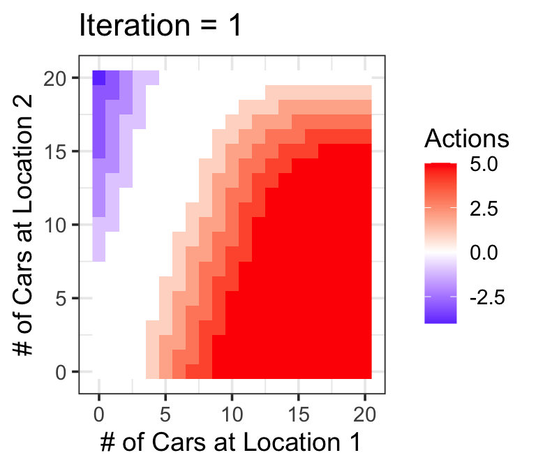

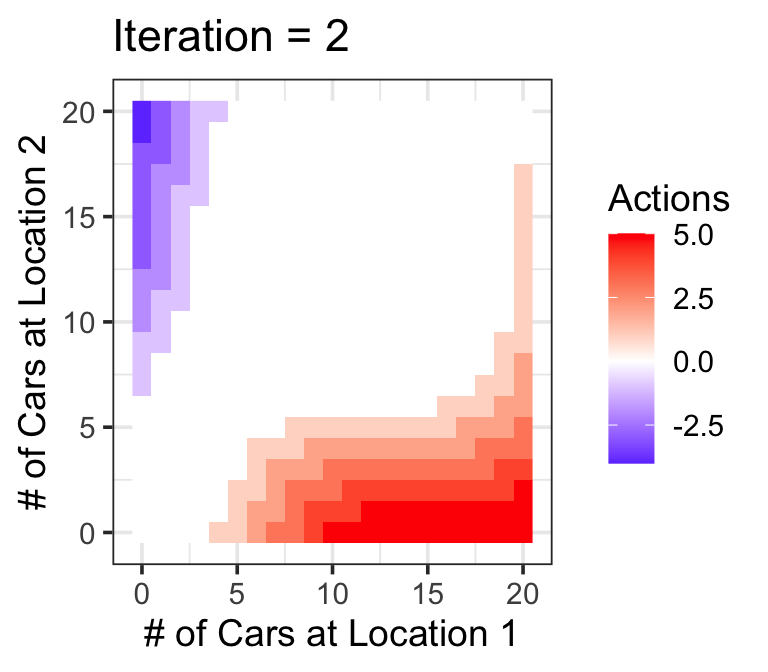

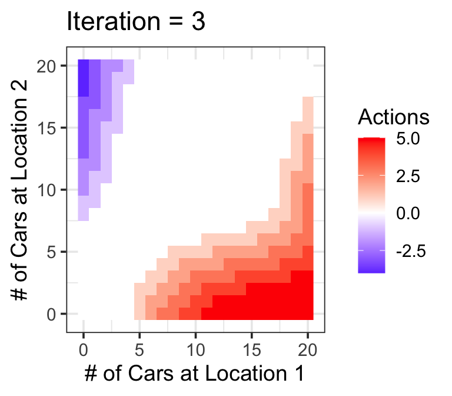

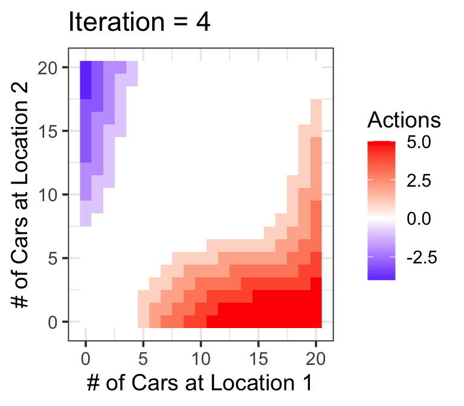

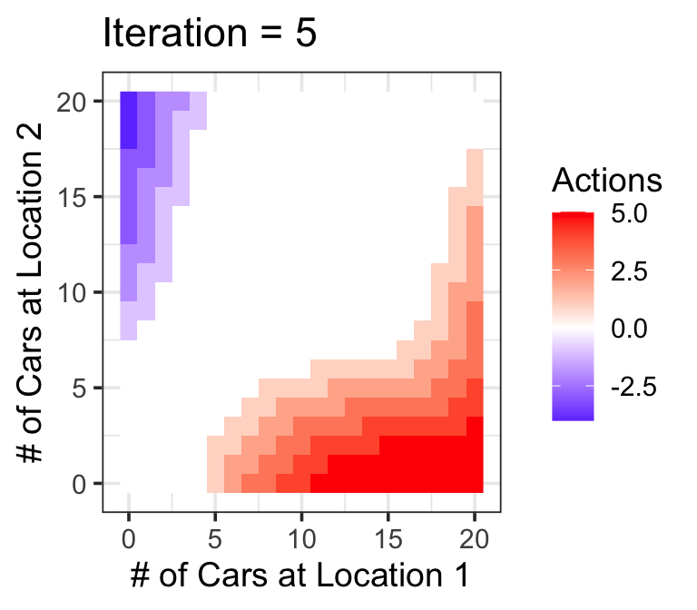

```r
library(ggplot2)
o <- policy_iter(gamma=0.9, policy0=policy0)
```

Visualize the value function under the optimal policy.

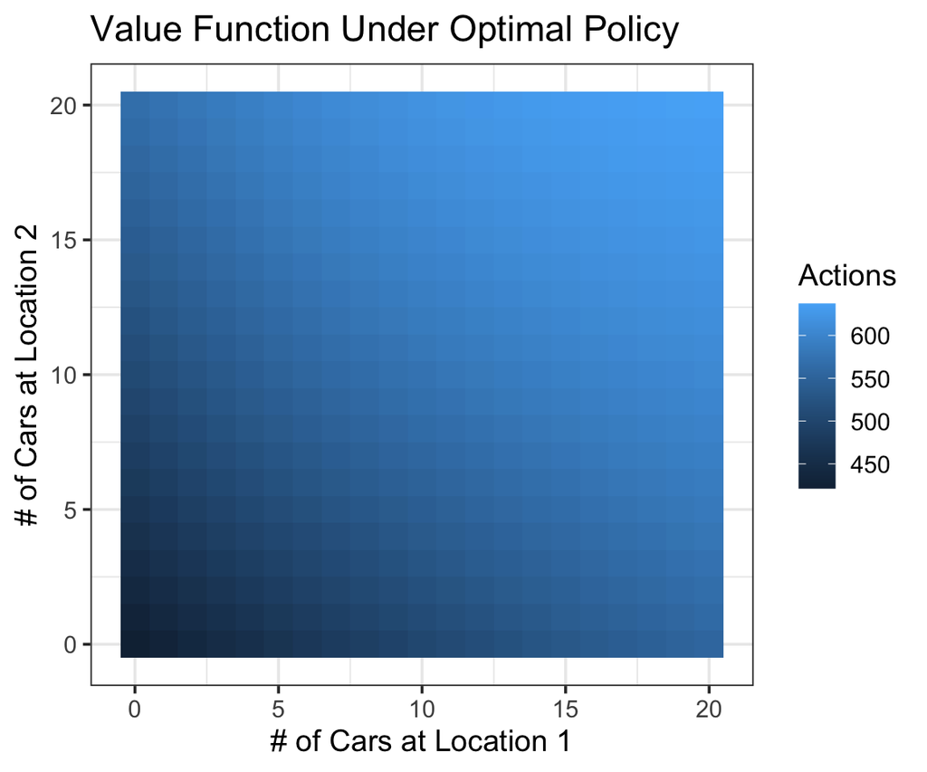

```r
print(plot_policy(c(o$V_mat), title="Value Function Under Optimal Policy",
                  if_policy=FALSE))
```